# Exploratory Data Analysis on Quality of Red Wine

Sai Saketh Boyanapalli

October 15, 2017

> **RedWineQualityDataSet**: This data set contains data on 1599 samples of red wines, there chemical Properties and quality. The inputs include objective tests and the output is based on sensory data from a wine expert(median of at least 3 evaluations from expert are taken)

I want to perform a exploratory data analysis on this data set to find interesting relationships between the different chemical properties and how they all relate to quality of the Red wine.

# Univariate Analysis

```r
str(redWine) # a look at structure of the data
```

```
## 'data.frame':    1599 obs. of  13 variables:
##  $ X                   : int  1 2 3 4 5 6 7 8 9 10 ...
##  $ fixed.acidity       : num  7.4 7.8 7.8 11.2 7.4 7.4 7.9 7.3 7.8 7.5 ...
##  $ volatile.acidity    : num  0.7 0.88 0.76 0.28 0.7 0.66 0.6 0.65 0.58 0.5 ...
##  $ citric.acid         : num  0 0 0.04 0.56 0 0 0.06 0 0.02 0.36 ...
##  $ residual.sugar      : num  1.9 2.6 2.3 1.9 1.9 1.8 1.6 1.2 2 6.1 ...
##  $ chlorides           : num  0.076 0.098 0.092 0.075 0.076 0.075 0.069 0.065 0.073 0.071 ...
##  $ free.sulfur.dioxide : num  11 25 15 17 11 13 15 15 9 17 ...
##  $ total.sulfur.dioxide: num  34 67 54 60 34 40 59 21 18 102 ...
##  $ density             : num  0.998 0.997 0.997 0.998 0.998 ...
##  $ pH                  : num  3.51 3.2 3.26 3.16 3.51 3.51 3.3 3.39 3.36 3.35 ...
##  $ sulphates           : num  0.56 0.68 0.65 0.58 0.56 0.56 0.46 0.47 0.57 0.8 ...
##  $ alcohol             : num  9.4 9.8 9.8 9.8 9.4 9.4 9.4 10 9.5 10.5 ...
##  $ quality             : int  5 5 5 6 5 5 5 7 7 5 ...
```

```r
names(redWine) # different variables in our data set.
```

```
##  [1] "X"                    "fixed.acidity"        "volatile.acidity"
##  [4] "citric.acid"          "residual.sugar"       "chlorides"
##  [7] "free.sulfur.dioxide"  "total.sulfur.dioxide" "density"
## [10] "pH"                   "sulphates"            "alcohol"
## [13] "quality"
```

```r
dim(redWine) # dimensions of our data.
```

```
## [1] 1599   13
```

```r
summary(redWine) # a brief summary of all variables in the data set.
```

```
##        X          fixed.acidity   volatile.acidity  citric.acid
##  Min.   :   1.0   Min.   : 4.60   Min.   :0.1200   Min.   :0.000
##  1st Qu.: 400.5   1st Qu.: 7.10   1st Qu.:0.3900   1st Qu.:0.090
##  Median : 800.0   Median : 7.90   Median :0.5200   Median :0.260
##  Mean   : 800.0   Mean   : 8.32   Mean   :0.5278   Mean   :0.271
##  3rd Qu.:1199.5   3rd Qu.: 9.20   3rd Qu.:0.6400   3rd Qu.:0.420
##  Max.   :1599.0   Max.   :15.90   Max.   :1.5800   Max.   :1.000
##  residual.sugar     chlorides       free.sulfur.dioxide
##  Min.   : 0.900   Min.   :0.01200   Min.   : 1.00
##  1st Qu.: 1.900   1st Qu.:0.07000   1st Qu.: 7.00
##  Median : 2.200   Median :0.07900   Median :14.00
##  Mean   : 2.539   Mean   :0.08747   Mean   :15.87
##  3rd Qu.: 2.600   3rd Qu.:0.09000   3rd Qu.:21.00
##  Max.   :15.500   Max.   :0.61100   Max.   :72.00
##  total.sulfur.dioxide    density             pH          sulphates
##  Min.   :  6.00       Min.   :0.9901   Min.   :2.740   Min.   :0.3300
##  1st Qu.: 22.00       1st Qu.:0.9956   1st Qu.:3.210   1st Qu.:0.5500
##  Median : 38.00       Median :0.9968   Median :3.310   Median :0.6200
##  Mean   : 46.47       Mean   :0.9967   Mean   :3.311   Mean   :0.6581
##  3rd Qu.: 62.00       3rd Qu.:0.9978   3rd Qu.:3.400   3rd Qu.:0.7300
##  Max.   :289.00       Max.   :1.0037   Max.   :4.010   Max.   :2.0000
##     alcohol         quality
##  Min.   : 8.40   Min.   :3.000
##  1st Qu.: 9.50   1st Qu.:5.000
##  Median :10.20   Median :6.000
##  Mean   :10.42   Mean   :5.636
##  3rd Qu.:11.10   3rd Qu.:6.000
##  Max.   :14.90   Max.   :8.000
```

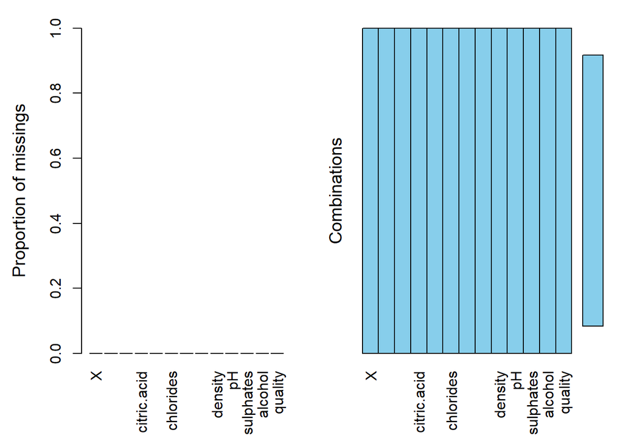

```r
aggr(redWine) # A look at missigness in our data (function taken from VIM library)
```

#### We can see that our data set is complete.

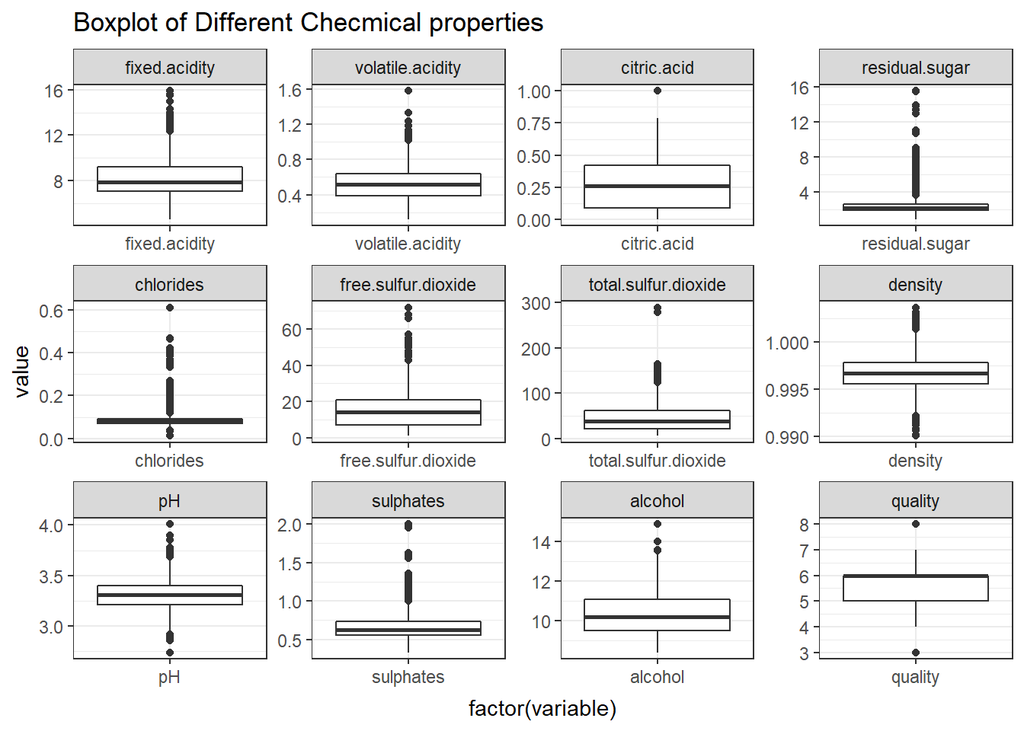

This boxplot is a good start to outlier identification we can see that few variables have lot of ouliers and some of them have only few outliers. we can get a better understanding by taking a look at each variable.

#### A look at how the data is distributed for each of the chemical properties

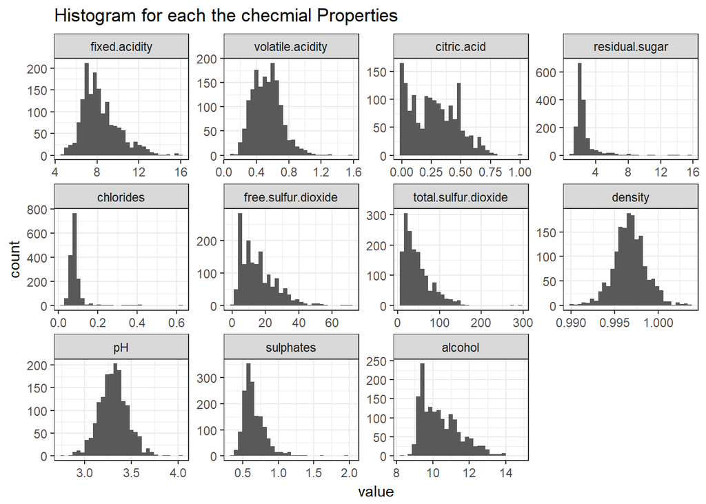

As indicated by the boxplot of chemical properties the plots with most outliers have skewed distributions in case of histogram.

Now we are left with few chemical properties which might need a closer look.

### Exploring Quality

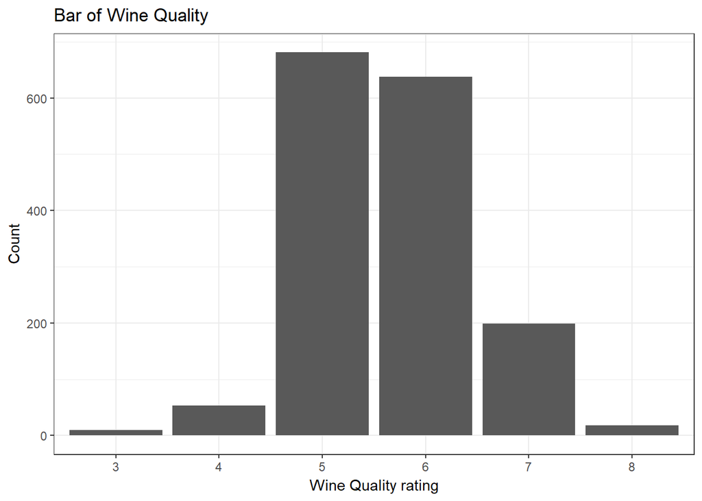

```
##    Min. 1st Qu.  Median    Mean 3rd Qu.    Max.
##   3.000   5.000   6.000   5.636   6.000   8.000
```

We can see that minimum rated quality is 3 in our data set and the best quality is 8, these were indicated as outliers in the above boxplot which means only few of the red wines received low quality and high quality rating and most of the ratings are in the middle. And another interesting finding is none of them received Highest quality rating - 10 or lowest quality rating - 0.

lets create factors for quality this might be useful later.

```r
redWine$qualityFactor <- factor(redWine$quality) # created new variable in data frame for quality factors.
```

Let’s look at other variables that are not normal.

### Exploring residual.sugar

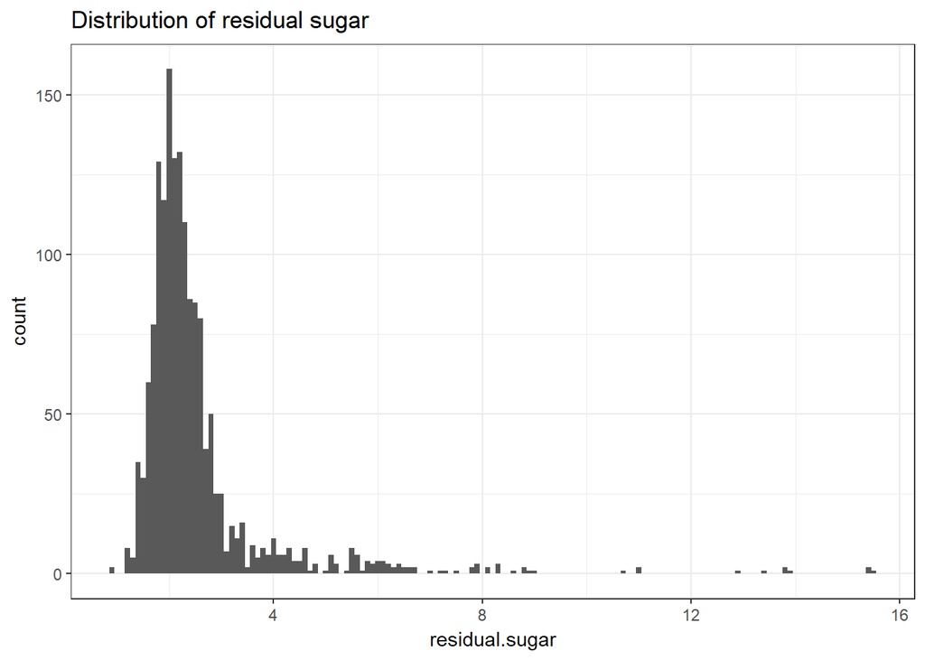

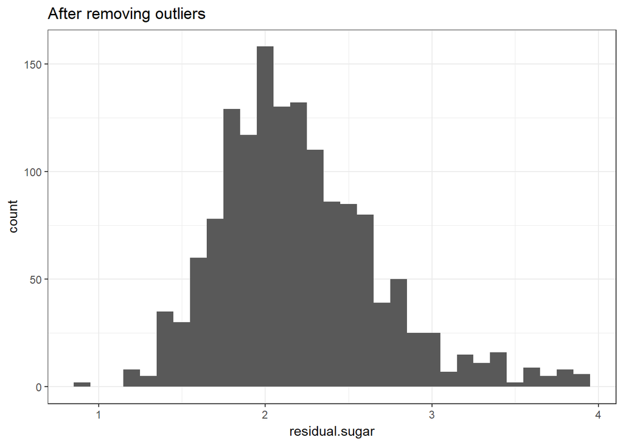

removing all the residual.sugar > 4 from the data the histogram changes from being skewed distibution to a normal distribution. We only have few samples with residual sugar content greater than 4 this might be due to less preference of sweety alcohol. This will be useful when modelling.

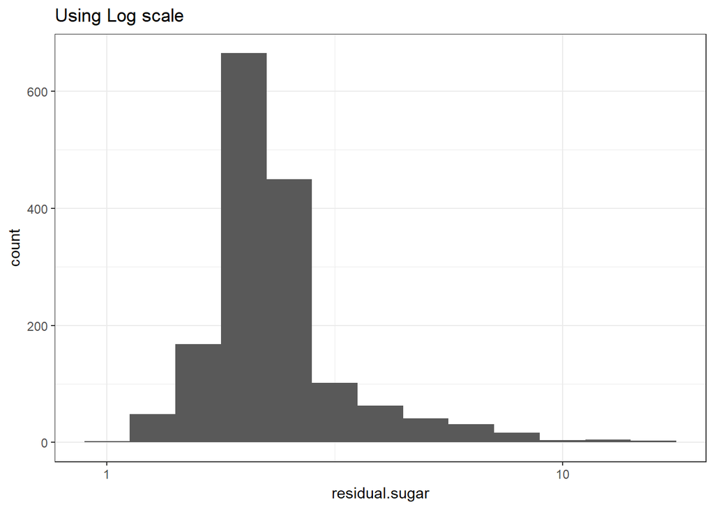

Applying log scale also yeilds close to normal distribution of data.

### Exploring citric acid

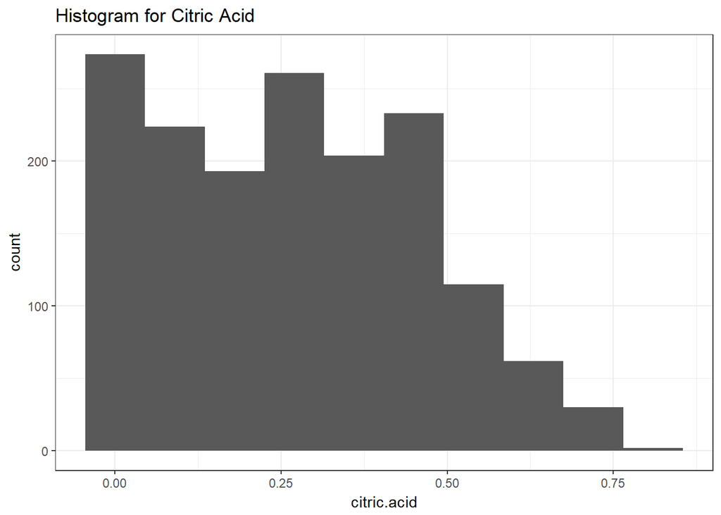

After removing outliers the distribution of citric acid is not normal. but instead close to uniform.

### Exploring Chlorides

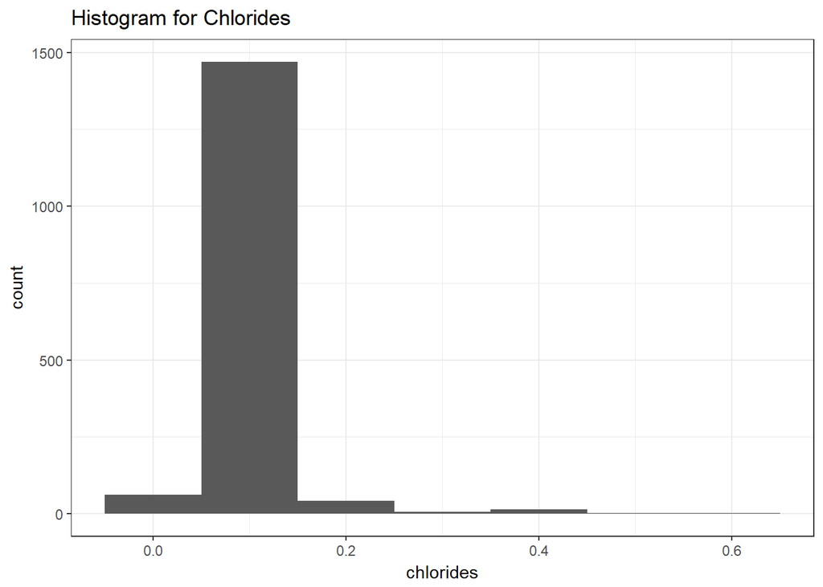

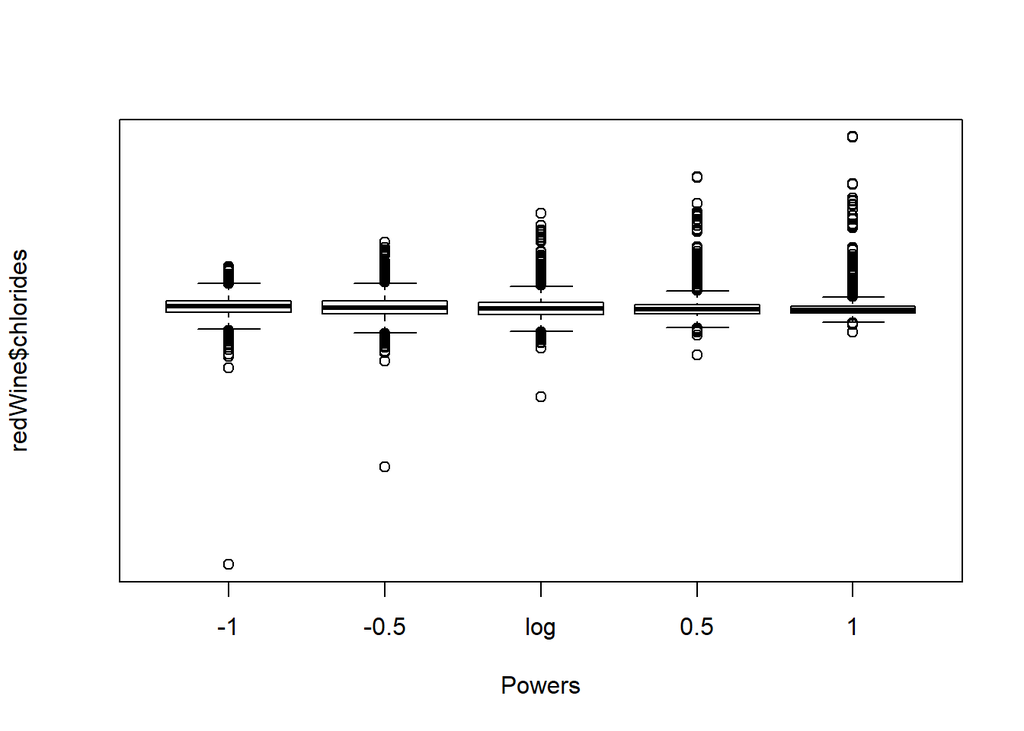

This symbox fuction will help us decide which powers will help us get closer to normal distribution for our data. if we look at the output of symbox fuction, the boxplot with few outliers will give us a power transformation which will distribute our data close to normal.

for chlorodes log transformation might yeild best result.

### Exploring free Sulfur.dioxide

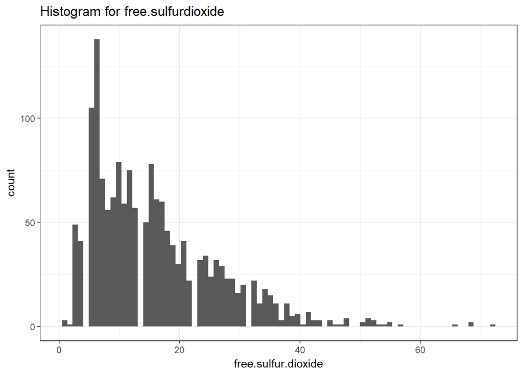

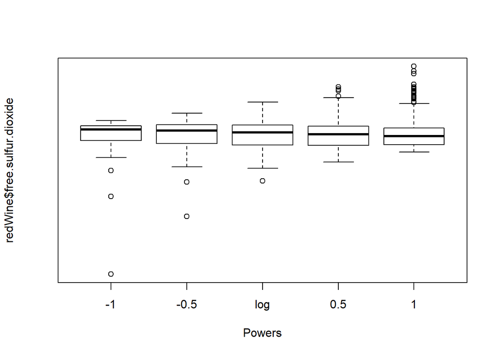

Looks like log transformation will yeild a distribution close to normal

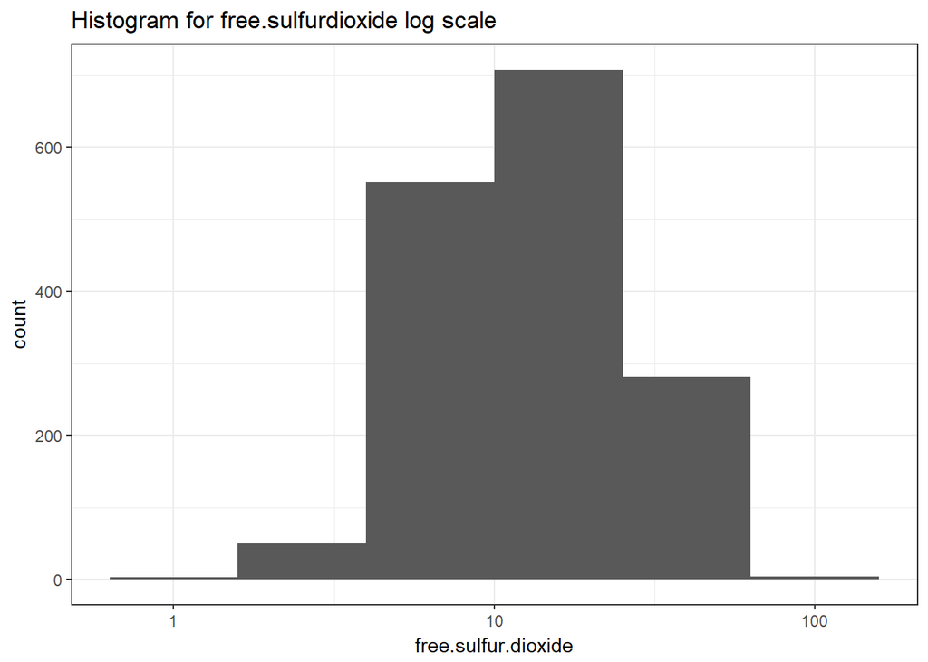

Our above assumptions seems to hold true this yeilds a close to normal distribution.

### Exploring Total sulfur.dioxide

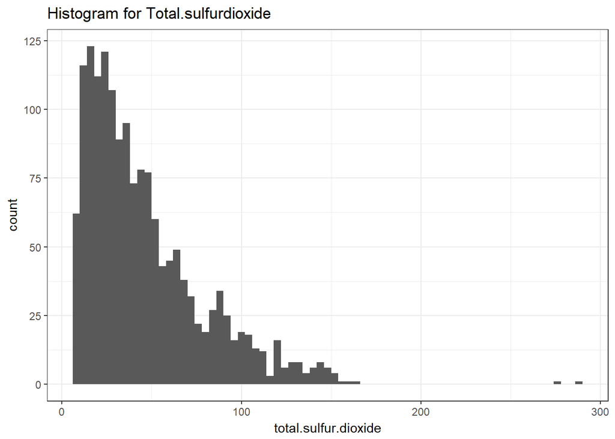

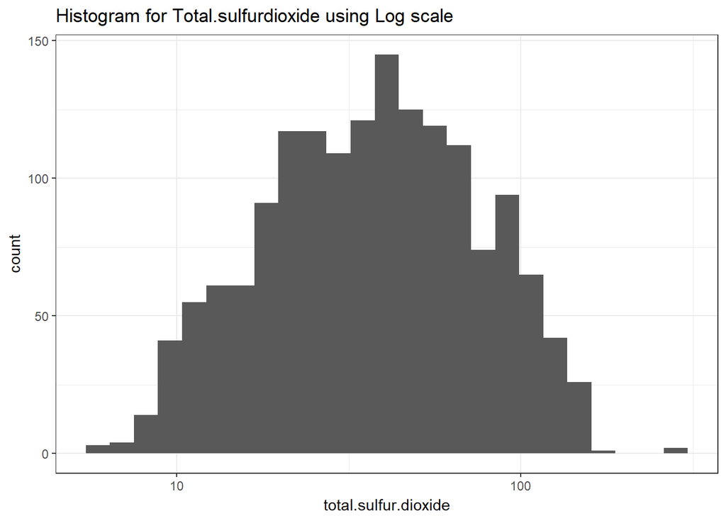

The similar trend follows here, the log transformation yeilds a close to normal distribution

### Exploring Sulphates

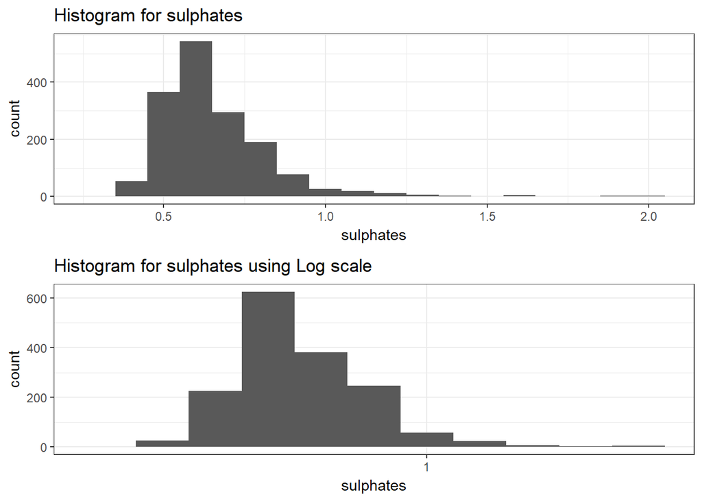

Similar trend for sulphates.

### Exploring Alcohol

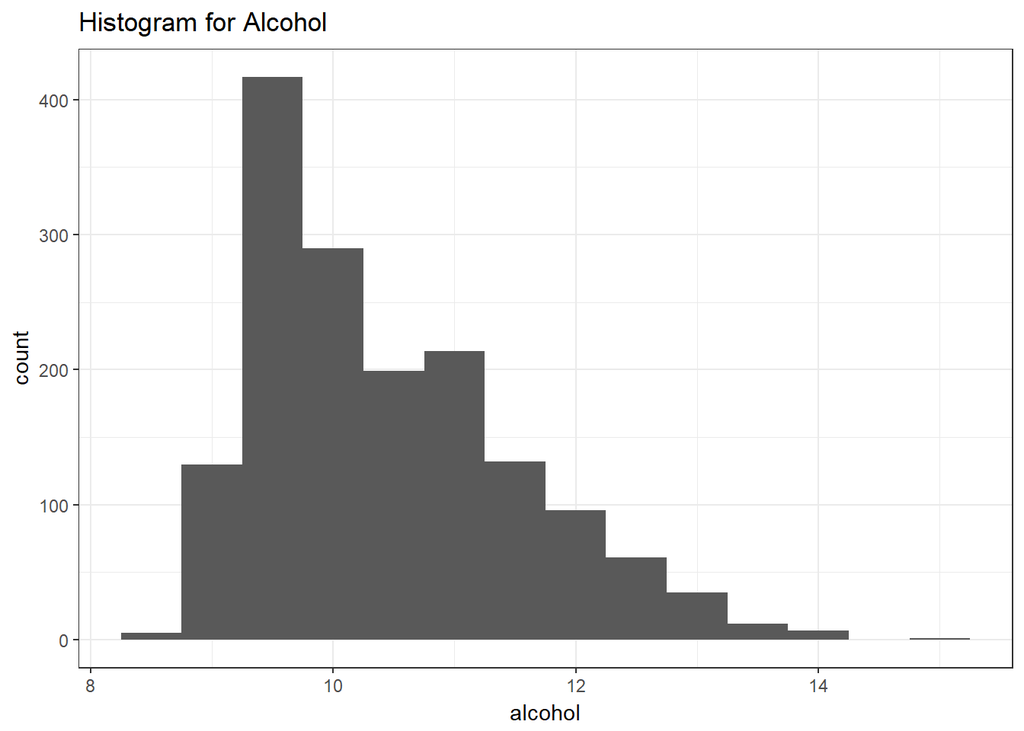

If we look at distributions for chemical properties they all tend to follow normal distributions when we change the scale to log10 for most of the distributions except for citric acid which seems to be closer to uniform distribution all the other follow close to normal distribution.

# Bivariate Plots Section

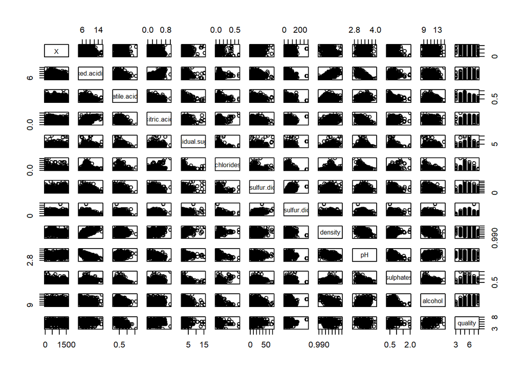

To look at relationship between all variables in data set

```
##                                 X fixed.acidity volatile.acidity
## X                     1.000000000   -0.26848392     -0.008815099
## fixed.acidity        -0.268483920    1.00000000     -0.256130895
## volatile.acidity     -0.008815099   -0.25613089      1.000000000
## citric.acid          -0.153551355    0.67170343     -0.552495685
## residual.sugar       -0.031260835    0.11477672      0.001917882
## chlorides            -0.119868519    0.09370519      0.061297772
## free.sulfur.dioxide   0.090479643   -0.15379419     -0.010503827
## total.sulfur.dioxide -0.117849669   -0.11318144      0.076470005
## density              -0.368372087    0.66804729      0.022026232
## pH                    0.136005328   -0.68297819      0.234937294
## sulphates            -0.125306999    0.18300566     -0.260986685
## alcohol               0.245122841   -0.06166827     -0.202288027
## quality               0.066452608    0.12405165     -0.390557780
##                      citric.acid residual.sugar    chlorides
## X                    -0.15355136   -0.031260835 -0.119868519
## fixed.acidity         0.67170343    0.114776724  0.093705186
## volatile.acidity     -0.55249568    0.001917882  0.061297772
## citric.acid           1.00000000    0.143577162  0.203822914
## residual.sugar        0.14357716    1.000000000  0.055609535
## chlorides             0.20382291    0.055609535  1.000000000
## free.sulfur.dioxide  -0.06097813    0.187048995  0.005562147
## total.sulfur.dioxide  0.03553302    0.203027882  0.047400468
## density               0.36494718    0.355283371  0.200632327
## pH                   -0.54190414   -0.085652422 -0.265026131
## sulphates             0.31277004    0.005527121  0.371260481
## alcohol               0.10990325    0.042075437 -0.221140545
## quality               0.22637251    0.013731637 -0.128906560
##                      free.sulfur.dioxide total.sulfur.dioxide     density
## X                            0.090479643          -0.11784967 -0.36837209
## fixed.acidity               -0.153794193          -0.11318144  0.66804729
## volatile.acidity            -0.010503827           0.07647000  0.02202623
## citric.acid                 -0.060978129           0.03553302  0.36494718
## residual.sugar               0.187048995           0.20302788  0.35528337
## chlorides                    0.005562147           0.04740047  0.20063233
## free.sulfur.dioxide          1.000000000           0.66766645 -0.02194583
## total.sulfur.dioxide         0.667666450           1.00000000  0.07126948
## density                     -0.021945831           0.07126948  1.00000000
## pH                           0.070377499          -0.06649456 -0.34169933
## sulphates                    0.051657572           0.04294684  0.14850641
## alcohol                     -0.069408354          -0.20565394 -0.49617977
## quality                     -0.050656057          -0.18510029 -0.17491923
##                               pH    sulphates     alcohol     quality
## X                     0.13600533 -0.125306999  0.24512284  0.06645261
## fixed.acidity        -0.68297819  0.183005664 -0.06166827  0.12405165
## volatile.acidity      0.23493729 -0.260986685 -0.20228803 -0.39055778
## citric.acid          -0.54190414  0.312770044  0.10990325  0.22637251
## residual.sugar       -0.08565242  0.005527121  0.04207544  0.01373164
## chlorides            -0.26502613  0.371260481 -0.22114054 -0.12890656
## free.sulfur.dioxide   0.07037750  0.051657572 -0.06940835 -0.05065606
## total.sulfur.dioxide -0.06649456  0.042946836 -0.20565394 -0.18510029
## density              -0.34169933  0.148506412 -0.49617977 -0.17491923
## pH                    1.00000000 -0.196647602  0.20563251 -0.05773139
## sulphates            -0.19664760  1.000000000  0.09359475  0.25139708
## alcohol               0.20563251  0.093594750  1.00000000  0.47616632
## quality              -0.05773139  0.251397079  0.47616632  1.00000000
```

Corelation between all variables in data set

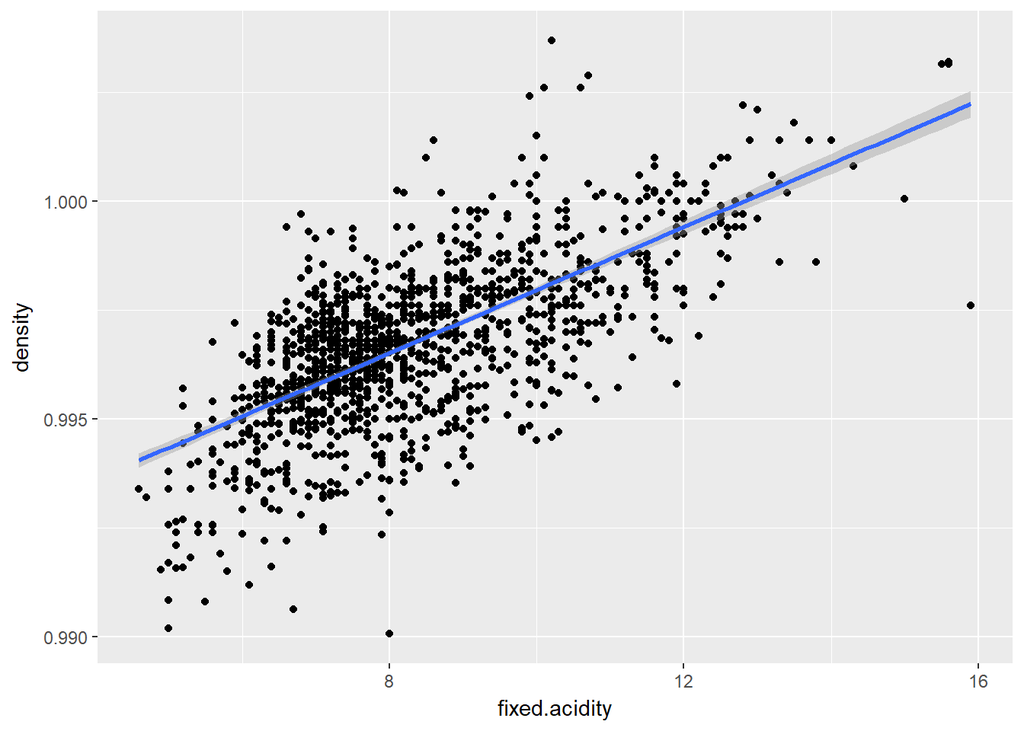

scatterplot for fixed acidity over density, this shows they are closely related.

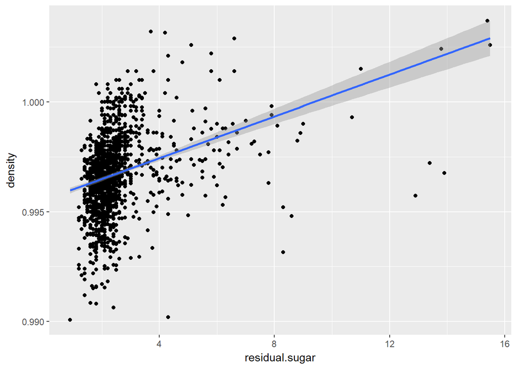

```
##
##  Pearson's product-moment correlation
##
## data:  redWine$residual.sugar and redWine$density
## t = 15.189, df = 1597, p-value < 2.2e-16
## alternative hypothesis: true correlation is not equal to 0
## 95 percent confidence interval:
##  0.3116908 0.3973835
## sample estimates:
##       cor
## 0.3552834
```

scatterplot for residual.sugar over density, this shows they are many outliers in the data.

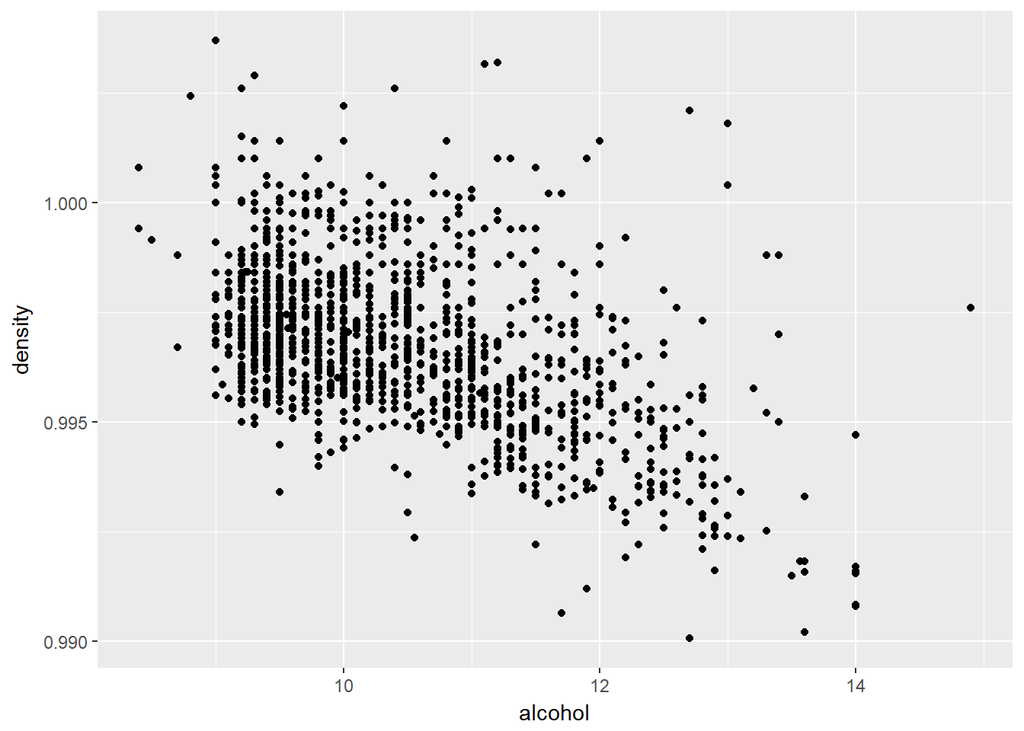

```
##
##  Pearson's product-moment correlation
##
## data:  redWine$alcohol and redWine$density
## t = -22.838, df = 1597, p-value < 2.2e-16
## alternative hypothesis: true correlation is not equal to 0
## 95 percent confidence interval:
##  -0.5322547 -0.4583061
## sample estimates:
##        cor
## -0.4961798
```

We can see a negative relationship between density over alcohol with correlation coefficeint -0.49

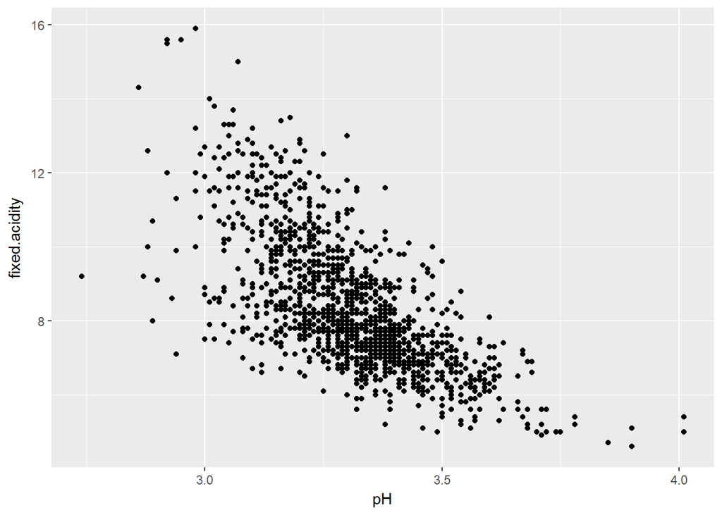

```
##
##  Pearson's product-moment correlation
##
## data:  redWine$fixed.acidity and redWine$pH
## t = -37.366, df = 1597, p-value < 2.2e-16
## alternative hypothesis: true correlation is not equal to 0
## 95 percent confidence interval:
##  -0.7082857 -0.6559174
## sample estimates:
##        cor
## -0.6829782
```

we can see that fixed acidity and ph are negatively correlated.

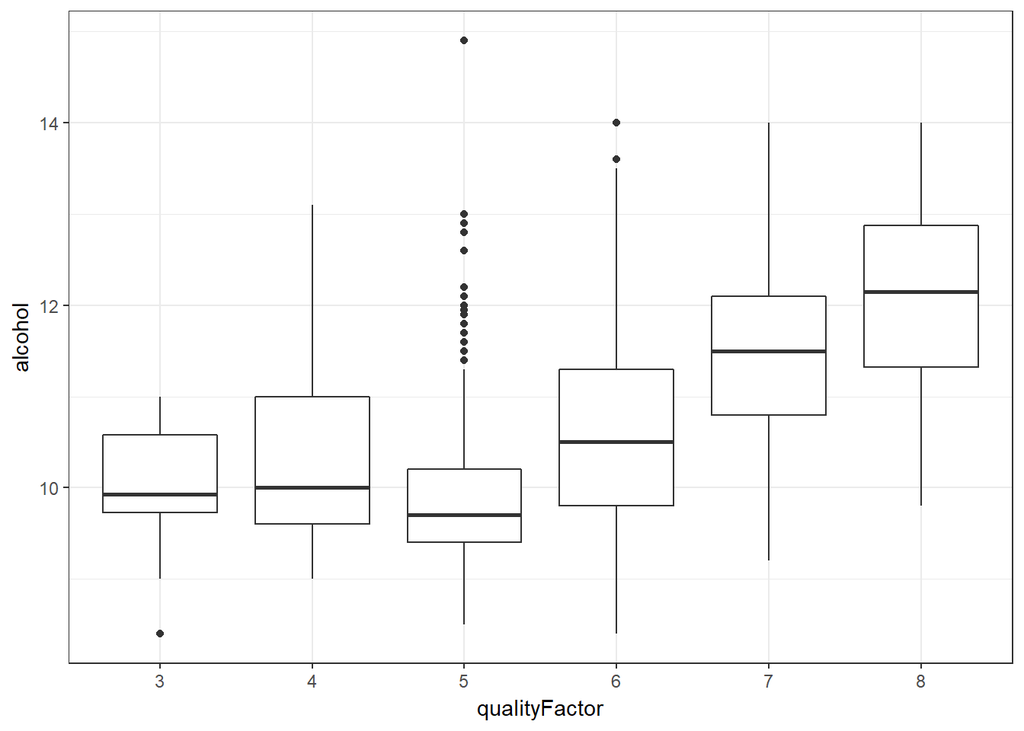

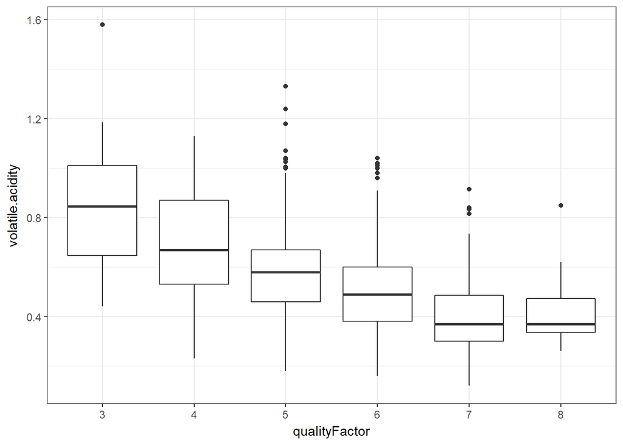

How does relationship of volatile acidity and quality change for different qualities of red wine. we can see mean volatile Acidity decreases with increase in qulaity of redWine.

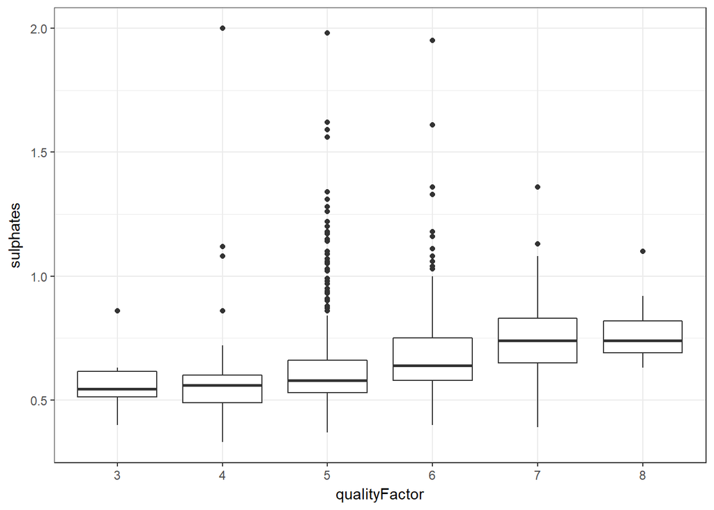

How does the mean of sulphates changes with quality.

In the above section I have created different plots to see if there is a relationship between quality and other chemical properties & realtionship between other chemical properties in general.

The plots that require further analysis to gain more insight were scatterplot matrix along with correlation coefficeint table, relationship between quality over alcohol, sulphates and volatile acidity.

Few relations between other chemical properties pH over fixed.acidity and density over fixed.acidity.